# Qualitative analysis of weight lifting exercises

Ray C Han

Friday, August 21, 2015

Intro Fitbit, Jawbone Up, and Nike FuelBand are devices which make it possible to collect a large amount of data about personal activity relatively cheaply. These type of instruments quantify self movement This project is to quantify how well an individual performs for a particular activity. In this project, the goal is to use data from accelerometers on the belt, forearm, arm, and dumbell of 6 participants. People were asked to perform barbell lifts correctly and incorrectly in 5 different ways. For reproducibility, I use set.seed, for prediction I use random forest to accomplish this for the reason that although it is difficult to interpret but often very precise.

Matching the specification exactly (A) With elbows thrown to the front (B) With dumbbell lifted only halfway (C) With dumbbell lowered only halfway (D) With hips thrown to the front (E). For more detail (Go to the part on the Weight Lifting Exercise Dataset) of the website http://groupware.les.inf.puc-rio.br/har

Data packages I use:

```r
rm(list=ls())
library(RCurl)
library(caret)
library(kernlab)
library(AppliedPredictiveModeling)
library(randomForest)
```

```r
library(ggplot2)
library(Metrics)
library(e1071)
```

Regarding this project the training data are available at: https://d396qusza40orc.cloudfront.net/predmachlearn/pml-training.csv The test data are available at: https://d396qusza40orc.cloudfront.net/predmachlearn/pml-testing.csv

```r
setwd('C:/Users/ALIENWARE/Desktop/Ray/PreMachineLearning')

training_data <- read.csv("pml-training.csv", na.strings=c("", "NA"))
test_data <- read.csv("pml-testing.csv", na.strings=c("", "NA"))
```

We remove the first column from the training data frame as it is just a place holder We also remove time and user information as they do not have any effect on the barbell lifts. Some columns in the data have mostly missing values. I delete features from the training and test data which have too many missing values, where it is not possible to impute

```r
training_data$X <- NULL
removecol <- c("user_name", "raw_timestamp_part_1",
                    "raw_timestamp_part_2", "cvtd_timestamp")
for (col in removecol) {
    training_data[, col] <- NULL
}
NAs <- apply(training_data,2,function(x) {sum(is.na(x))})
training_data <- training_data[,which(NAs == 0)]
```

I deleted characteristics that don’t have a lot of missing values but have one unique value (such as zero variance predictors) or have few unique values relative to the number of samples and the ratio of frequency of the most common value to the frequency of second most common value is big

```r
nzv <- nearZeroVar(training_data)
training_data <- training_data[-nzv]
test_data <- test_data[-nzv]
names(training_data)
```

```
##  [1] "num_window"           "roll_belt"            "pitch_belt"
##  [4] "yaw_belt"             "total_accel_belt"     "gyros_belt_x"
##  [7] "gyros_belt_y"         "gyros_belt_z"         "accel_belt_x"
## [10] "accel_belt_y"         "accel_belt_z"         "magnet_belt_x"
## [13] "magnet_belt_y"        "magnet_belt_z"        "roll_arm"
## [16] "pitch_arm"            "yaw_arm"              "total_accel_arm"
## [19] "gyros_arm_x"          "gyros_arm_y"          "gyros_arm_z"
## [22] "accel_arm_x"          "accel_arm_y"          "accel_arm_z"
## [25] "magnet_arm_x"         "magnet_arm_y"         "magnet_arm_z"
## [28] "roll_dumbbell"        "pitch_dumbbell"       "yaw_dumbbell"
## [31] "total_accel_dumbbell" "gyros_dumbbell_x"     "gyros_dumbbell_y"
## [34] "gyros_dumbbell_z"     "accel_dumbbell_x"     "accel_dumbbell_y"
## [37] "accel_dumbbell_z"     "magnet_dumbbell_x"    "magnet_dumbbell_y"
## [40] "magnet_dumbbell_z"    "roll_forearm"         "pitch_forearm"
## [43] "yaw_forearm"          "total_accel_forearm"  "gyros_forearm_x"
## [46] "gyros_forearm_y"      "gyros_forearm_z"      "accel_forearm_x"
## [49] "accel_forearm_y"      "accel_forearm_z"      "magnet_forearm_x"
## [52] "magnet_forearm_y"     "magnet_forearm_z"     "classe"
```

```r
set.seed(1)
observe <- c()
predict <- c()
for(i in 1:10) {
    processtrain = sample(1:dim(training_data)[1], size=dim(training_data)[1] * 0.8,
    replace=F)
    training_cross = training_data[processtrain,]
    test_cross = training_data[-processtrain,]
    randomf <- randomForest(classe ~ ., data=training_cross)
    observe <- c(observe, test_cross$classe)
    predict <- c(predict, predict(randomf, test_cross))
}
confusion_mat <- confusionMatrix(table(predict, observe))
confusion_mat$table
```

```
##        observe
## predict     1     2     3     4     5
##       1 11099     7     0     0     0
##       2     1  7456    10     0     0
##       3     0     3  6836    32     0
##       4     0     0     3  6470     7
##       5     2     0     0     2  7322
```

```r
model <- randomForest(classe ~ ., data=training_data)
```

Submission #prepare the test and model data

```r
# Function to write to files
predict_write = function(x){
  l = length(x)
  for(i in 1:l){
    Name= paste0("identity_",i,".txt")
    write.table(x[i],file=Name,quote=FALSE,row.names=FALSE,col.names=FALSE)
    }
  }

# Results
library(randomForest)
library(caret)
results <- predict(model, test_data)

# write answers to files
predict_write(results)
```

Conclusion Confusion matrix is relatively accurate.

References 1)The Elements of Statistical Learning: Data Mining, Inference, and Prediction By Trevor Hastie 2)Machine Learning By Tom M. Mitchell 3)Pattern Recognition and Machine Learning By Christopher M. Bishop

```r
library(ggplot2)
# ggplot(model)
```

[figure not shown]

```r
resize.win <- function(Width=6, Height=6){
  # windows
  dev.off();
  windows(record=TRUE, width=Width, height=Height)
}
resize.win(5,5)
plot(rnorm(100))
```

[figure not shown]

```r
resize.win(10,10)
plot(rnorm(100))
```

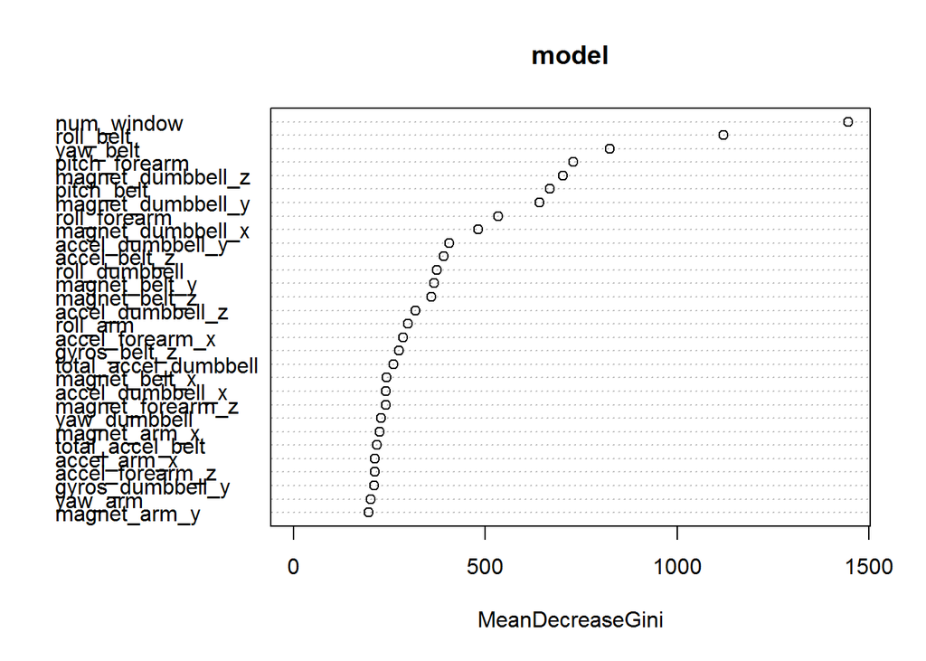

```r
varImpPlot(model)
```